# Esports Earnings 1998 - 2021

# Installing Packages

```r
install.packages("tidyverse")
install.packages("readr")
```

# Calling the Packages Library

```r
library(tidyverse)
library(readr)
```

# Importing the Data set of Esports Earnings

```r
Esports <- read.csv("GeneralEsportData.csv")

Esports
```

| Game | ReleaseDate | Genre | TotalEarnings | OnlineEarnings | TotalPlayers | TotalTournaments |
| --- | --- | --- | --- | --- | --- | --- |
| Age of Empires | 1997 | Strategy | 191181.81 | 156839.89 | 261 | 99 |
| Age of Empires II | 1999 | Strategy | 2280004.90 | 720999.87 | 1508 | 1107 |
| Age of Empires III | 2005 | Strategy | 93913.65 | 41800.00 | 139 | 120 |
| Age of Empires IV | 2021 | Strategy | 75765.25 | 217.00 | 115 | 56 |
| Age of Empires Online | 2011 | Strategy | 5283.56 | 775.00 | 22 | 16 |
| Age of Mythology | 2002 | Strategy | 100551.00 | 52000.00 | 129 | 121 |
| Among Us | 2018 | Strategy | 86000.00 | 0.00 | 14 | 8 |
| Auto Chess | 2019 | Strategy | 1143720.28 | 1037122.28 | 123 | 36 |
| Brawl Stars | 2018 | Strategy | 2557950.00 | 1336250.00 | 215 | 31 |
| Chess.com | 2007 | Strategy | 1826564.33 | 0.00 | 771 | 272 |

[output cut: 542 more lines]

# Fig 1: Bar Graph

### x : ReleaseDate

### y : TotalTournaments

### fill : Genre

## The Data set will be filter to feature only the Release Dates between 1998-2005.

```r
# The Data set will be filter to feature only the Release Dates greater than or equal to 1998 and less than or equal to 2005

dataFilter <- filter(Esports, ReleaseDate >= 1998 & ReleaseDate <= 2005)
```

[output not shown]

## After filtering the data, it will than be process for selection to specified specific columns like (Release Date, Total Tournaments, and Genre).

```r
# The data after filtering will than be process for selection of specific columns of (Release Date, Total Tournaments, and Genre).

barGraph <- select(dataFilter,ReleaseDate, TotalTournaments, Genre)

barGraph
```

| ReleaseDate | TotalTournaments | Genre |
| --- | --- | --- |
| 1999 | 1107 | Strategy |
| 2005 | 120 | Strategy |
| 2002 | 121 | Strategy |
| 1999 | 0 | Strategy |
| 2000 | 7 | Strategy |
| 2002 | 9 | Strategy |
| 1998 | 686 | Strategy |
| 2002 | 1335 | Strategy |
| 2005 | 3 | Strategy |
| 2001 | 1 | First-Person Shooter |

[output cut: 91 more lines]

## Finally, the final process will than be used to create our bar graph of total tournaments withing an 8 year period while being fill with the Genre column to specify which genre was used.

## Then labels were given to the graph to help the viewer understand what is going on.

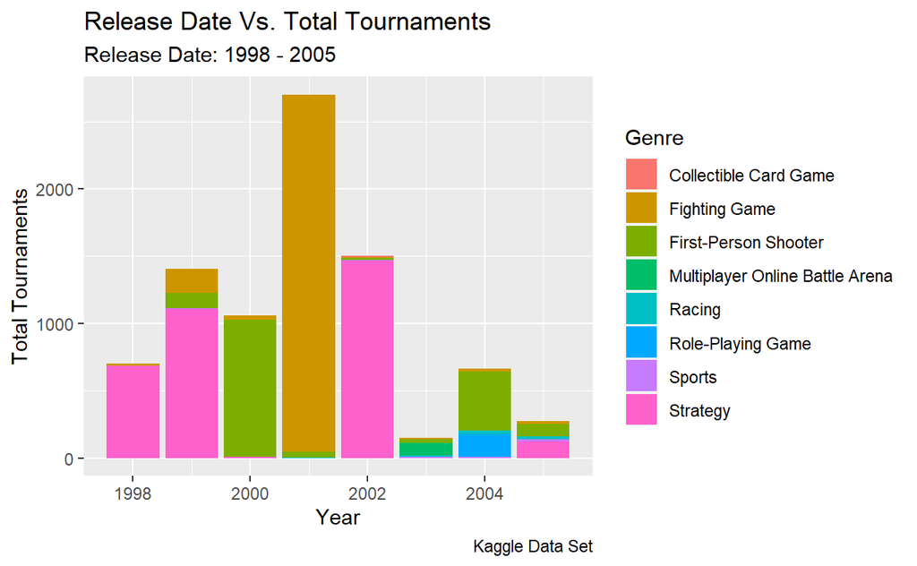

```r
# Finally, the final process will than be used to create our bar graph of total tournaments withing a an 8 year period while being fill with the Genre column so specify which genre was used. The labels were also given to the graph to help the viewer understand what is going on.

ggplot(data = barGraph, mapping = aes(x = ReleaseDate, y = TotalTournaments, fill = Genre, bins = 17)) + geom_bar(stat = "identity") + labs(title = "Release Date Vs. Total Tournaments", subtitle = "Release Date: 1998 - 2005", x = "Year", y = "Total Tournaments", caption = "Kaggle Data Set")
```

Follow up: This plot helps us understand the number of tournaments that have occurred in an 8-year span between 1998 - 2005 of different genres for Esport. Furthermore, the graph explains to us that in a certain year one genre was superior in terms of total tournaments. For example, In the year 2001, one genre was dominant in the total tournament categories which were Fighting Game.

# Fig 2: Pie Chart

### x : OnlineEarnings

### y : Genre

### fill : Genre

## Created a new data sets that has filter values of release dates between 2000-2005 and Online Earnings $2,000- $40,000.

## This choice was made to please the viewer with better visuals. The data set alone with only filtering release date will be to much data that the visuals will be all mush together making it hard to read.

## Therefore, the decision was made to make the data set even smaller for better visuals.

```r
# Created a new data sets with values that are filter for Release Date greater than or equal to 2000 and less than or equal to 2005. Furthermore, the filter is extended further by making the Online Earnings less than or equal to 40000 and greater than or equal to 2000.

# This choice was made to please the viewer with better visuals. The data set alone with only filtering release date will be to much data that the visuals will be all mush together making it hard to read. Therefore, the decision was made to make the data set even smaller for better visuals.

genreEarnings <- filter(Esports, ReleaseDate >= 2000 & ReleaseDate <= 2005 & OnlineEarnings <= 40000 & OnlineEarnings >= 2000)

genreEarnings
```

| Game | ReleaseDate | Genre | TotalEarnings | OnlineEarnings | TotalPlayers | TotalTournaments |
| --- | --- | --- | --- | --- | --- | --- |
| Aliens versus Predator 2 | 2001 | First-Person Shooter | 40000.00 | 40000.00 | 1 | 1 |
| Day of Defeat: Source | 2005 | First-Person Shooter | 14068.57 | 10286.47 | 50 | 8 |
| Star Wars Jedi Knight II: Jedi Outcast | 2002 | First-Person Shooter | 7679.25 | 7679.25 | 0 | 1 |
| Capcom vs. SNK 2 | 2001 | Fighting Game | 24246.79 | 24246.79 | 37 | 20 |
| Dead or Alive Ultimate | 2004 | Fighting Game | 30000.00 | 30000.00 | 3 | 1 |
| Guilty Gear XX Slash | 2005 | Fighting Game | 10250.00 | 10250.00 | 6 | 2 |
| Hyper Street Fighter II | 2003 | Fighting Game | 10250.00 | 10250.00 | 8 | 1 |
| Marvel vs. Capcom 2 | 2000 | Fighting Game | 39060.00 | 39050.00 | 60 | 28 |
| Soul Calibur II | 2003 | Fighting Game | 4980.00 | 4980.00 | 17 | 8 |
| Tekken 4 | 2001 | Fighting Game | 12500.00 | 12500.00 | 4 | 4 |

[output cut: 12 more lines]

## Once the GenreEarnings data set is establish, now comes the selection of columns to paste on my pie chart. The columns used where OnlineEarnings and Genre from the GenreEarnings Data set.

```r
# Once the GenreEarnings data set is establish, now comes the selection of columns to paste on my pie chart. The columns used where OnlineEarnings and Genre from the GenreEarnings Data set.

pieSelect <- select(genreEarnings, OnlineEarnings, Genre)

pieSelect
```

| OnlineEarnings | Genre |
| --- | --- |
| 40000.00 | First-Person Shooter |
| 10286.47 | First-Person Shooter |
| 7679.25 | First-Person Shooter |
| 24246.79 | Fighting Game |
| 30000.00 | Fighting Game |
| 10250.00 | Fighting Game |
| 10250.00 | Fighting Game |
| 39050.00 | Fighting Game |
| 4980.00 | Fighting Game |
| 12500.00 | Fighting Game |

[output cut: 12 more lines]

## Finally the pie chart may be made with our columns that we had chosen before. To make the visual easier to read I decided to fill the pie chart with the genre columns.

## The labels were also given to the graph to help the viewer understand what is going on.

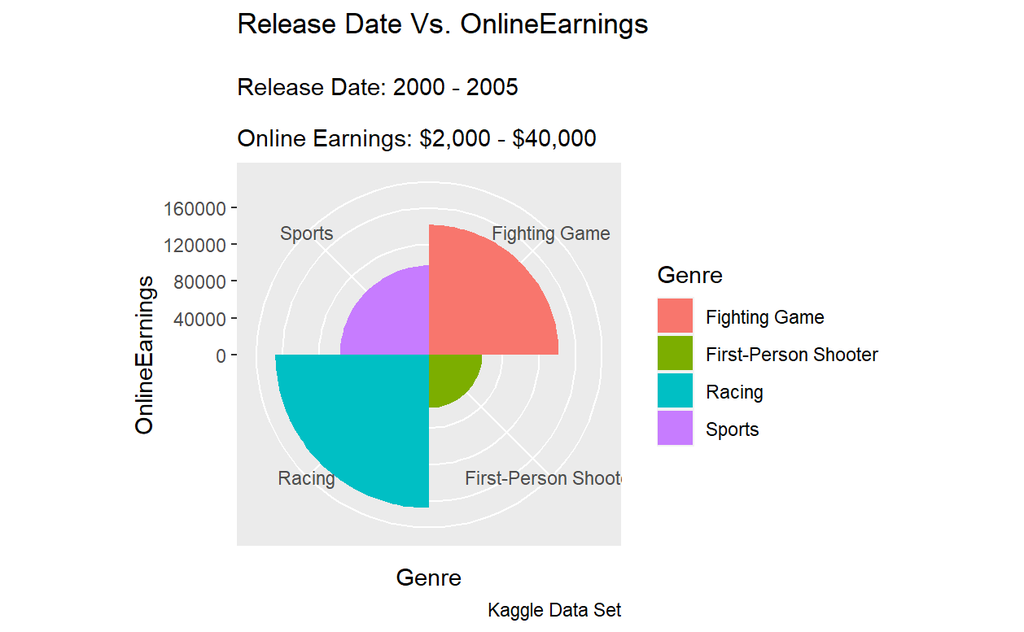

```r
# Finally the pie chart may be made with our columns that we had chosen before. To make the visual easier to read I decided to fill the pie chart with the genre columns. The labels were also given to the graph to help the viewer understand what is going on.

ggplot(data = pieSelect, aes(x= OnlineEarnings, y = Genre, fill= Genre)) + geom_bar(stat="identity", width=1) + coord_polar("y", start=0) + labs(title = "Release Date Vs. OnlineEarnings", subtitle = "\nRelease Date: 2000 - 2005\n\nOnline Earnings: $2,000 - $40,000", x = "OnlineEarnings", y = "Genre", caption = "Kaggle Data Set")
```

Follow up: This plot helps understand the different genres in terms of specific release date range by a range of 2,000 to 40,000 Online Earnings. To establish this visual I created a new data set that has filter values of release dates between 2000-2005 and Online Earnings “$2,000 - $40,000”. It’s important because it helps us establish which genre from a specific year range has the most Online Earnings from the various types of genre.

# Fig 3: Scatter Plot

### x : OnlineEarnings

### y : Release Date

### color : Genre

## Since the data set of GenreEarnings is a valid short set of small values. I decided to reused the same data set and only change the selection section by adding Release Date.

```r
# Since the data set of GenreEarnings is a valid short set of small values. I decided to reused the same data set and only change the selection section by adding Release Date.

scatterPlot <- select(genreEarnings, OnlineEarnings, ReleaseDate, Genre)

scatterPlot
```

| OnlineEarnings | ReleaseDate | Genre |
| --- | --- | --- |
| 40000.00 | 2001 | First-Person Shooter |
| 10286.47 | 2005 | First-Person Shooter |
| 7679.25 | 2002 | First-Person Shooter |
| 24246.79 | 2001 | Fighting Game |
| 30000.00 | 2004 | Fighting Game |
| 10250.00 | 2005 | Fighting Game |
| 10250.00 | 2003 | Fighting Game |
| 39050.00 | 2000 | Fighting Game |
| 4980.00 | 2003 | Fighting Game |
| 12500.00 | 2001 | Fighting Game |

[output cut: 12 more lines]

## The plot was design to show the online earnings at specific release dates from different genres.

## Uses the same points, except the y-axis is replace with Release Date to represent different online earnings on the specific year is was release.

## The labels were also given to the graph to help the viewer understand what is going on.

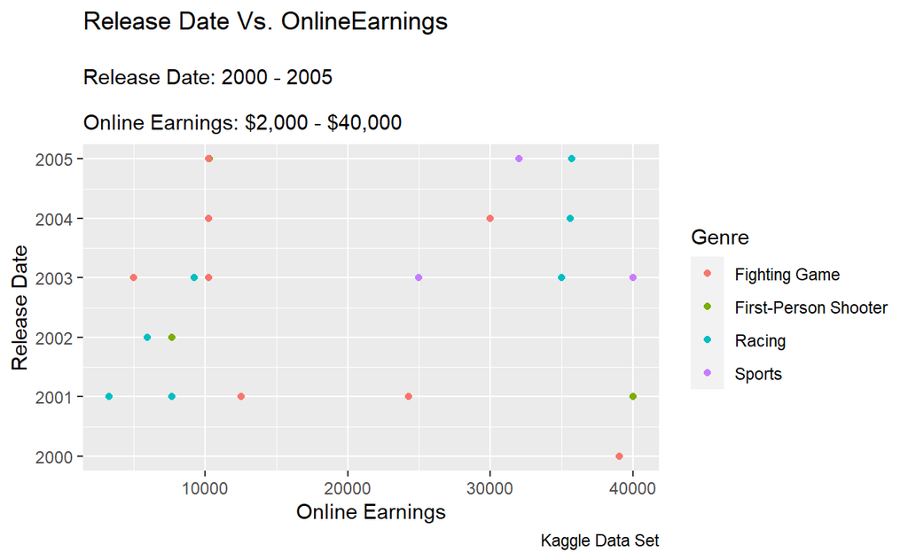

```r
# The plot was design to show the online earnings at specific release dates from different genres. Uses the same points, except the y-axis is replace with Release Date to represent different online earnings on the specific year is was release. The labels were also given to the graph to help the viewer understand what is going on.


ggplot(data = scatterPlot, mapping = aes(x = OnlineEarnings, y = ReleaseDate, color = Genre)) + geom_point() + labs(title = "Release Date Vs. OnlineEarnings", subtitle = "\nRelease Date: 2000 - 2005\n\nOnline Earnings: $2,000 - $40,000",x = "Online Earnings", y = "Release Date", caption = "Kaggle Data Set")
```

Follow up: This plot helps understand the different genres in terms of specific release date range by a range of 2,000 to 40,000 Online Earnings. To establish this visual I created a new data set that has filter values of release dates between 2000-2005 and Online Earnings “$2,000 - $40,000”. It’s important because it helps us establish which genre from a specific year range has the most Online Earnings from the various types of genre. The only difference between the pie chart and scatter plot is that the scatter plot gives us a specific visual of each earning on a given date. For example, the genre of first-person shooting in 2001 earn a grand total of $40,000 on Online Earnings.

# Fig 4: Line Plot

### x : OnlineEarnings

### y : Release Date

### color : Genre

## Since the data set of GenreEarnings is a valid short set of small values. I decided to reused the same data set and only change the selection section by adding Release Date.

```r
# Since the data set of GenreEarnings is a valid short set of small values. I decided to reused the same data set and only change the selection section by adding Release Date.

linePlot <- select(genreEarnings, OnlineEarnings, ReleaseDate, Genre)

linePlot
```

| OnlineEarnings | ReleaseDate | Genre |
| --- | --- | --- |
| 40000.00 | 2001 | First-Person Shooter |
| 10286.47 | 2005 | First-Person Shooter |
| 7679.25 | 2002 | First-Person Shooter |
| 24246.79 | 2001 | Fighting Game |
| 30000.00 | 2004 | Fighting Game |
| 10250.00 | 2005 | Fighting Game |
| 10250.00 | 2003 | Fighting Game |
| 39050.00 | 2000 | Fighting Game |
| 4980.00 | 2003 | Fighting Game |
| 12500.00 | 2001 | Fighting Game |

[output cut: 12 more lines]

## The plot was design to show the online earnings at specific release dates from different genres.

## Uses the same points, except the y-axis is replace with Release Date to represent different online earnings on the specific year is was release.

## The labels were also given to the graph to help the viewer understand what is going on.

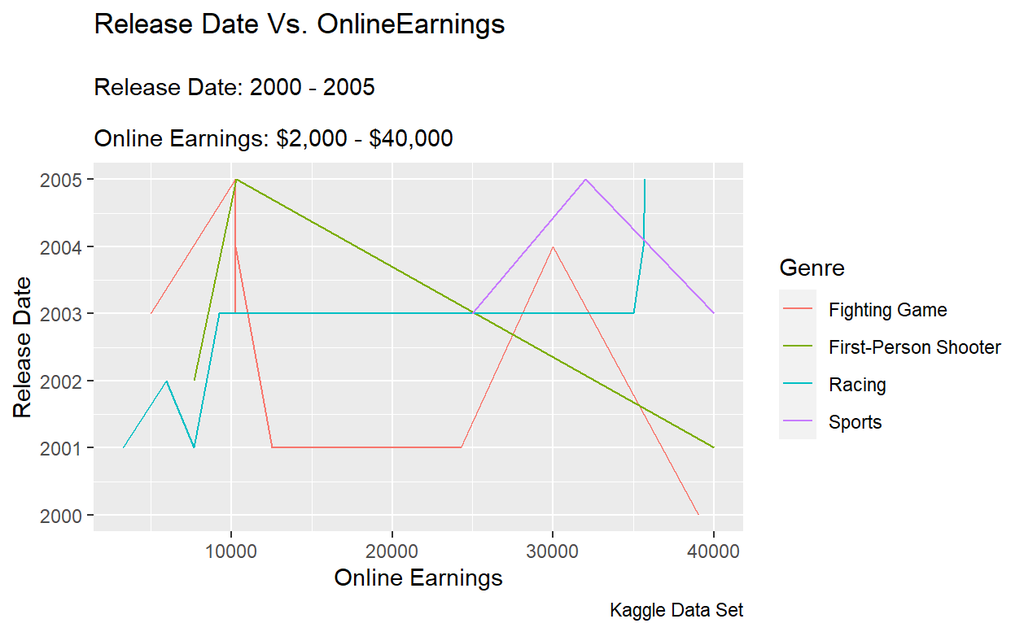

```r
# The plot was design to show the online earnings at specific release dates from different genres. Uses the same points, except the y-axis is replace with Release Date to represent different online earnings on the specific year is was release. The labels were also given to the graph to help the viewer understand what is going on.


ggplot(data = linePlot, mapping = aes(x = OnlineEarnings, y = ReleaseDate, color = Genre)) + geom_line() + labs(title = "Release Date Vs. OnlineEarnings", subtitle = "\nRelease Date: 2000 - 2005\n\nOnline Earnings: $2,000 - $40,000",x = "Online Earnings", y = "Release Date", caption = "Kaggle Data Set")
```

Follow up: The plot was designed to show the online earnings at specific release dates from different genres. Uses the same points, except the y-axis is replaced with Release Date to represent different online earnings on the specific year it was released. The labels were also given to the graph to help the viewer understand what is going on. It helps in terms of understanding what decreases and increase throughout a given year in terms of Online Earnings.